# Traditional Geostatistics

In this chapter, we begin with an example of a simple Kriging prediction with covariance parameters estimated from a variogram. Next, we show why one should be cautious using a variogram to estimate parameters, and finally we recommend alternatives to variogram fitting.

##Fitting a Variogram

Consider the following spatial data: we have measurements of the daily maximum temperature in Colorado during March, April, and May (MAM) at several hundred locations, along with the elevation at each longitude/latitude pair. We want to predict the temperature value at $\mathbf x_0 = (-103,39.5)$.

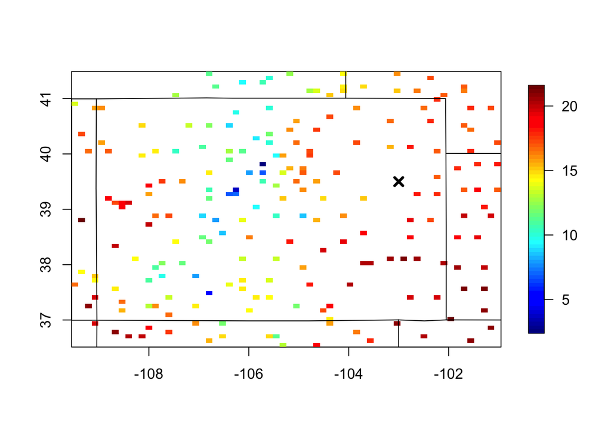

```r
data(COmonthlyMet)
y.CO <- CO.tmax.MAM.climate
z.CO <- CO.elev
grd.CO <- as.matrix(CO.loc)
keep <- !is.na(y.CO)      #removing all NA's from the data
y.CO <- y.CO[keep]
z.CO <- z.CO[keep]
grd.CO <- grd.CO[keep,]
quilt.plot(grd.CO,y.CO)
US(add=TRUE)
points(-103,39.5, pch=4,lwd=3,cex=1.25, col='black')
```

For now, we’ll assume a zero mean ($\mathbf Z\mathbf{d} \equiv \mathbf 0$) and focus on the spatial aspect, which is clearly an incorrect assumption. One can remove the mean trend using least squares, but then this requires universal Kriging instead of simple Kriging. We prefer to start with simple Kriging in this exposition. Details for universal Kriging can be done in the appendix. Denote our locations of observed points as $\mathbf x_1,\dots,\mathbf x_n$. In this example, $n=213$ since we have 213 temperature observations.

Suppose we want to predict the temperature $Y(\cdot)$ at a new location $\mathbf x_0$. Recall that the simple Kriging estimate $\hat Y(\mathbf x_0)$ of our mean zero Gaussian process $Y(\cdot)$ is given by:
$$\hat Y(\mathbf x_0) = \Sigma_0 \Sigma^{-1} \mathbf Y$$

Now, the question is how to determine the covariance function of $Y(\cdot)$. For this example, we’ll consider the (isotropic) exponential covariance: $\operatorname{Cov}[ Y(\mathbf x), Y(\mathbf x')] = \rho e^{ - \| \mathbf x - \mathbf x'\|/a }$. Here, $a $ is a range parameter that corresponds to the length of spatial autocorrelation of our process, and $\rho$ is the overall variance of the process.

The covariance matrix $\Sigma$ thus has $i,j$-th entry
$$\Sigma_{i,j} = e^{ - \| \mathbf x_i - \mathbf x_j\|/a } + \sigma^2 \mathbf{1}_{ \{ \mathbf x_i = \mathbf x_j \} },$$
where $\mathbf{1}_{ \{ \mathbf x_i = \mathbf x_j \} }= \begin{cases} 1 & \mathbf x_i = \mathbf x_j \\ 0 & \text{else} \end{cases}$

Earlier, we defined the variogram, which measures how our data $Y(\mathbf x)$ is related over distance. To find paramters $(a ,\rho,\sigma^2)$ for the covariance function, a common geostatistical approach is to fit a curve to the (binned) semivariogram. Since we are working with longitudinal and latitudinal data, we use the option `lon.lat=TRUE`.

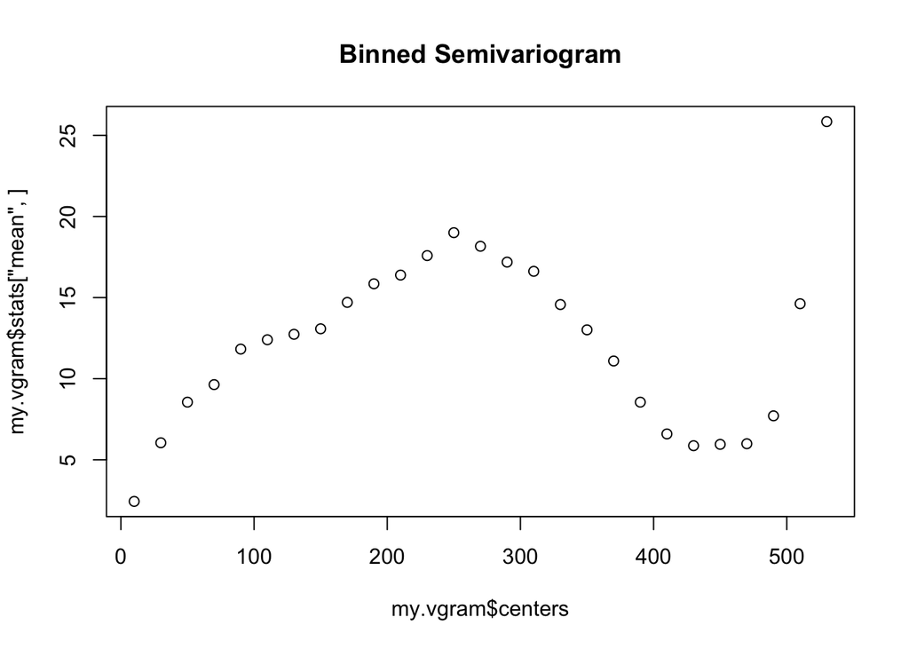

```r
my.vgram <- vgram(loc=grd.CO,y=y.CO,N=30,lon.lat=TRUE) #use 30 bins
plot(my.vgram$stats["mean",]~my.vgram$centers,main='Binned Semivariogram')
```

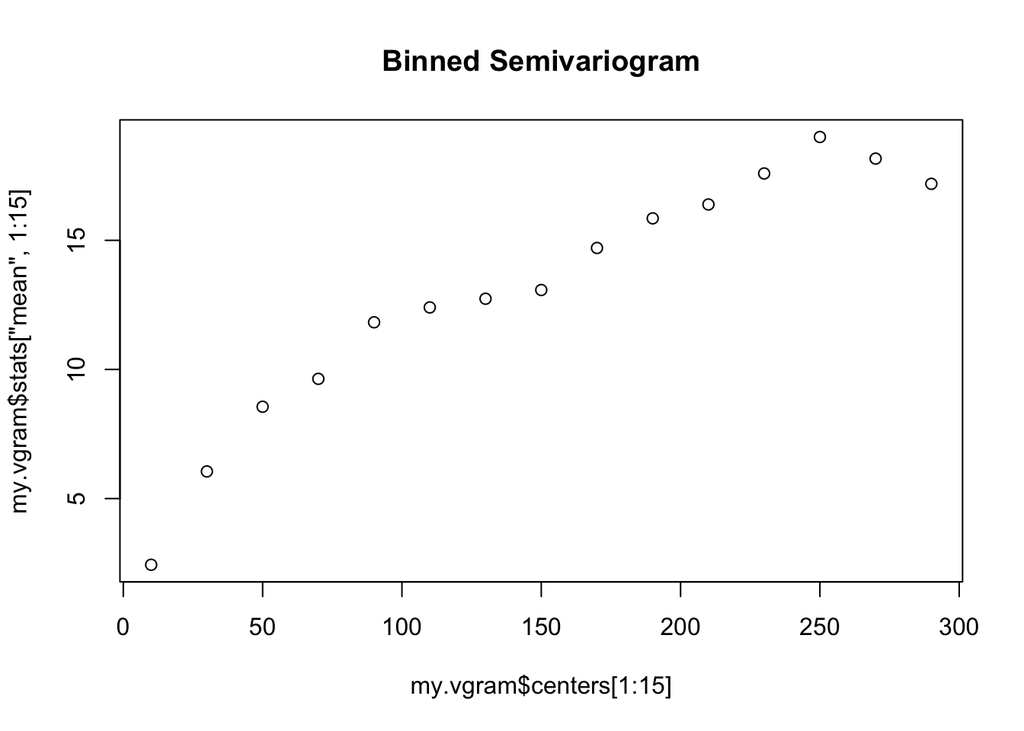

```r
plot(my.vgram$stats["mean",1:15]~my.vgram$centers[1:15],main='Binned Semivariogram')
```

Next, we fit parameters to the above semivariogram using least squares and `L-BFGS` optimization, an alternative to fitting by eye. The exponential variogram formula is as follows:
$$\gamma(r) = \begin{cases}
\rho \left(1- e^{-r/a } \right) + \sigma^2 & r >0 \\
0 & r=0
\end{cases}$$
The Matern semivariogram (with smoothing parameter $\nu$) is:
$$\gamma(r) = \begin{cases}
\rho \left(1- \frac{2^{1-\nu}}{\Gamma(\nu)} \left( \frac{ r}{a } \right)^\nu K_\nu \left( \frac{r}{a } \right) \right) + \sigma^2 & r >0 \\
0 & r=0
\end{cases}$$

In each case, we minimize least squares to find estimates of the covariance parameters.

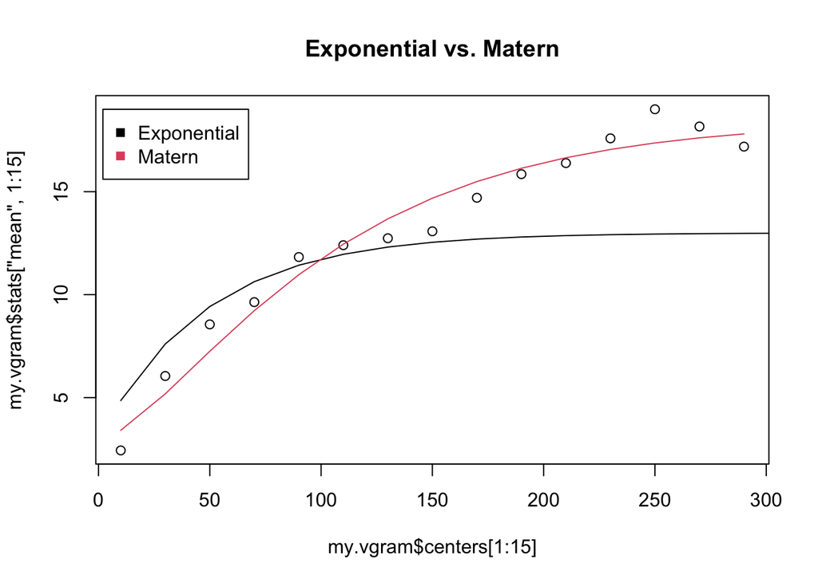

```r
#Exponential plot
ls.exponential <- function(par){ # par = (rho,aRange,sigma^2)
    theoretical.vgram <- par[1] * (1 - exp(-my.vgram$centers[1:15] / par[2])) + par[3]
    sum( (theoretical.vgram - my.vgram$stats["mean",1:15])^2 ) }

##providing initial guesses and bounds
out.exponential <- optim(par=c(2,50,1),fn=ls.exponential,method="L-BFGS", lower = c(0,0,0), upper = c(10,100,3))

rho.exponential <- out.exponential$par[1]
aRange.exponential <- out.exponential$par[2]
sigma2.exponential <- out.exponential$par[3]

plot(my.vgram$stats["mean",1:15]~my.vgram$centers[1:15], main="Exponential vs. Matern")
lines(c(sigma2.exponential + rho.exponential*(1-exp(-my.vgram$centers/aRange.exponential)))~my.vgram$centers,col=1)

#Matern plot
ls.matern <- function(par){ # par = (rho,aRange,nu,sigmasq)
    theoretical.vgram <- par[1] * (1 - Matern(my.vgram$centers[1:15], range= par[2], nu = par[3])) + par[4]
    sum((theoretical.vgram - my.vgram$stats["mean",1:15])^2 )  }

##providing initial guesses and bounds
out.matern <- optim(par=c(2,50,2.5,1),fn=ls.matern,method="L-BFGS", lower = c(0,0,1,0), upper = c(25,100,6,3))

rho.matern <- out.matern$par[1]
aRange.matern <- out.matern$par[2]
nu.matern <- out.matern$par[3]
sigma2.matern <- out.matern$par[4]

lines(c(sigma2.matern + rho.matern*(1-Matern(my.vgram$centers[1:15],range = aRange.matern, nu = nu.matern )))~my.vgram$centers[1:15],col=2)

legend(x=2, y=19 ,legend=c("Exponential","Matern"),col=c(1,2),pch=15, cex=1)
```

It is clear that the Matern correlation provides a better fit to the binned sample variogram. Therefore, we use the estimated Matern covariance function for prediction.

##Kriging predictor

To compute our prediction at $\mathbf x_0$, we use this set of parameters along with the kriging predictor $\Sigma_0 \Sigma^{-1} \mathbf Y$. Since we have assumed an isotropic Matern covariance, the $\Sigma_0$ and $\Sigma^{-1}$ matrices are easily computed with the `rdist.earth` function.

```r
x0 <- as.matrix(cbind(-103,39.5))   #rdist only takes matrices
dist0.mat <- rdist.earth(grd.CO,x0)
dist.mat <- rdist.earth(grd.CO,grd.CO)

Sigma0 <- rho.matern * Matern(dist0.mat, range=aRange.matern, nu=nu.matern)
Sigma <- rho.matern * Matern(dist.mat, range=aRange.matern, nu=nu.matern)
diag(Sigma) <- diag(Sigma) + sigma2.matern
Sigma.inverse <- solve(Sigma)

weights <- t(Sigma0) %*% Sigma.inverse
prediction <- weights %*% y.CO
```

The predicted value at $\mathbf x_0$ is calculated above, and after plotting, we see that it is reasonable given the neighboring values.

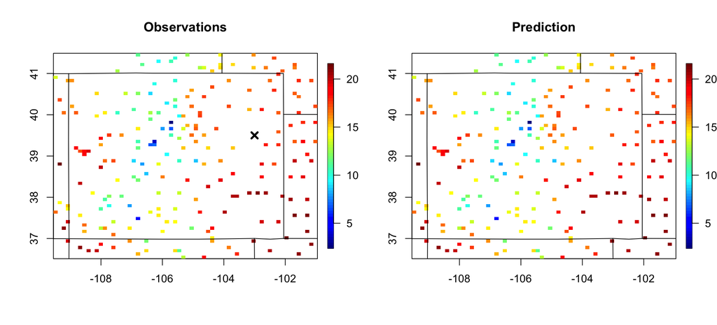

```r
set.panel(1,2)
quilt.plot(grd.CO,y.CO, main="Observations")
US(add=TRUE)
points(-103,39.5, pch=4,lwd=3,cex=1.25, col='black')

grd.x0 <- rbind(grd.CO,x0)
y.x0 <- c(y.CO,prediction)
quilt.plot(grd.x0,y.x0,main='Prediction')
US(add=TRUE)
```

Here are the spatial weights for each spatial location when predicting the value at $\mathbf x_0$.

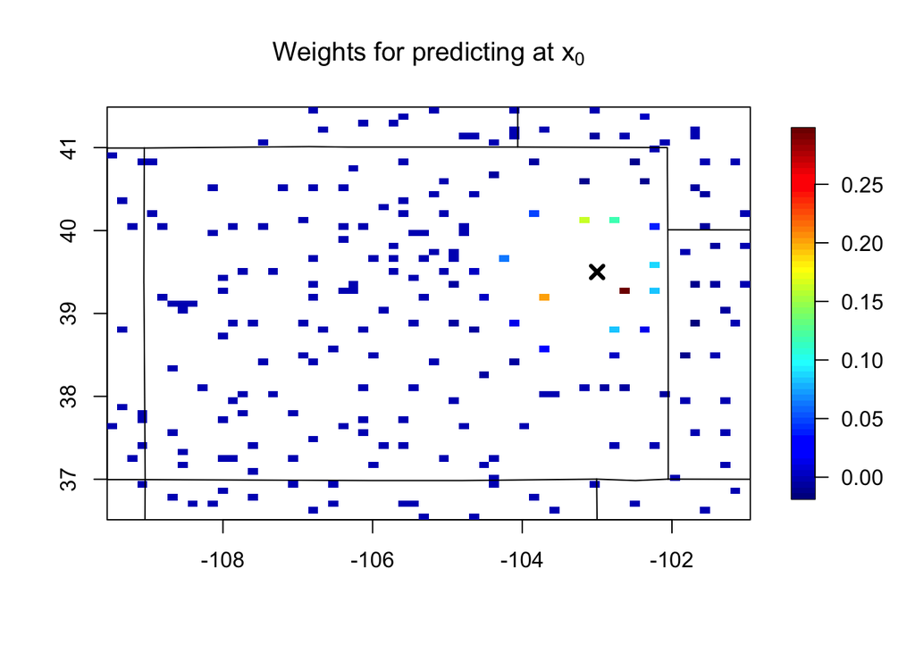

```r
quilt.plot(grd.CO,weights)
title(expression('Weights for predicting at x'[0]))
points(-103,39.5, pch=4,lwd=3,cex=1.25, col='black')
US(add=TRUE)
```

We could easily extend $\mathbf x_0$ to be a vector of locations at which we want to predict.

```r
lonvals <- seq(min(CO.loc[,1]),max(CO.loc[,1]),length.out=100)
latvals <- seq(min(CO.loc[,2]),max(CO.loc[,2]),length.out=100)
pred.grd <- as.matrix(expand.grid(lonvals,latvals))
```

The kriging estimate at each location follows after modifying $\Sigma_0$.

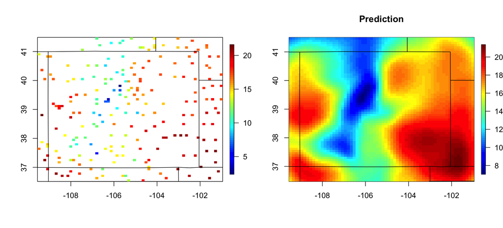

```r
dist0.mat <- rdist.earth(grd.CO,pred.grd)
Sigma0 <- rho.matern * Matern(dist0.mat, range=aRange.matern, nu=nu.matern)
grid.predictions <-  t(Sigma0) %*% Sigma.inverse %*% y.CO

set.panel(1,2)
quilt.plot(grd.CO,y.CO)
US(add=TRUE)
quilt.plot(pred.grd,grid.predictions,main='Prediction')
US(add=TRUE)
```

Recall that we assumed that the process has mean zero, which is clearly inaccurate. The `fields` package creates a mean function consisting of a low-order polynomial in the spatial coordinates. When Kriging, we often wish to use an additional covariate to help estimate the mean. For example, consider the following plot of elevation in Colorado:

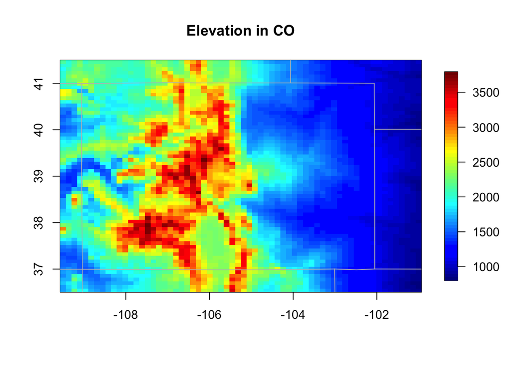

```r
quilt.plot(make.surface.grid(CO.Grid),CO.elevGrid$z)
title("Elevation in CO")
US(add=TRUE,col='grey')
```

The elevation plot is a near inverse of our prediction grid – this agrees with our intuition that there are lower temperatures at higher elevations. If we include a covariate `Z` corresponding to elevation, then we can produce even more accurate predictions (a sneak-peek is shown below).

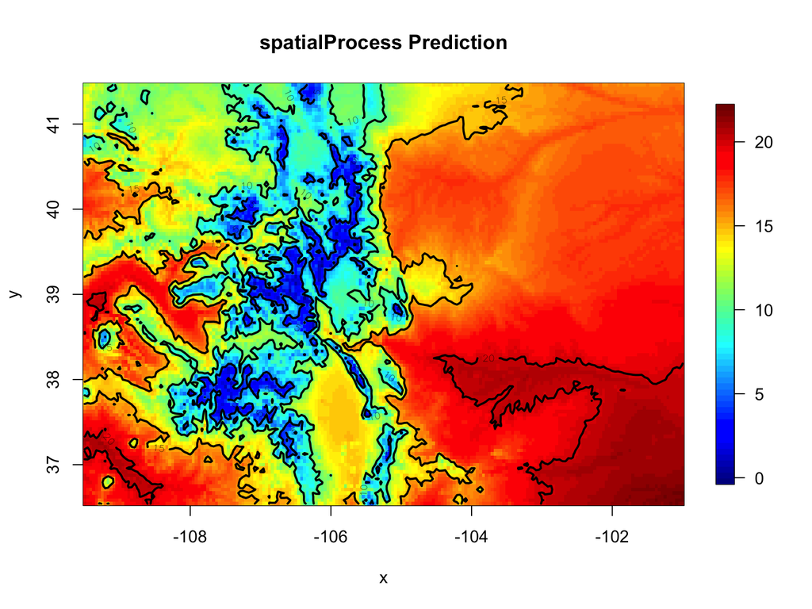

##The Problem with Fitting a Variogram

Variogram fitting is often a poor representation of the underlying structure of an isotropic process. Below, we generate several random fields, and then compare the corresponding variograms to the true correlation functions.

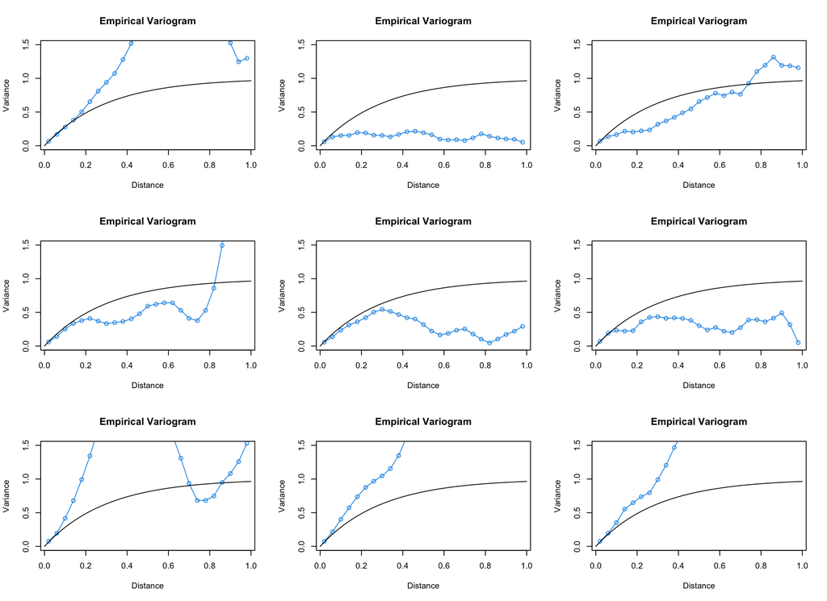

```r
n <- 100
x <- matrix(seq(0,1,,n), nc=1)
d <- rdist(x)
cov <- Exponential(d, range=0.3)
cov.c <- chol(cov)

x0 <- 0  #getting the true variogram gamma(h) = C(0) - C(h)
d0 <- rdist(x0,x)
c0 <- Exponential(d0, range=0.3)
e0 <- (1-c0[1,])

vg <- list()
brk<- seq( 0, 1,, (25 + 1) )
set.panel(3,3)
for (i in 1:9){
  sim <- t(cov.c)%*%rnorm(n)
  vg[[i]] <- vgram(x, sim, N=25)
  plot(vg[[i]], breaks=brk, col=4, ylim=c(0,1.5))  #plot simulated variogram
  lines(x,e0)
}
```

Note that the fits of the sample variogram are poor estimates of the true correlation function, and they are particularly flawed at larger distances. For this reason, curve-fitting to the binned sample variogram is an unreliable method of estimating the underlying covariance parameters. Instead, parameters must be found through Maximum Likelihood Estimation (MLE) or Generalized Cross Validation. The top level `fields` functions `spatialProcess` and `mKrig` both automate these estimation methods for the covariance parameters.